# LightGBM Challenger

Does a flexible model find signal the scorecard misses?

Evan Reynolds

2026-11-01

## The Short Version

+0.029

Gini uplift over the scorecard

Retain and review interactions

Verdict under 1.1a

A gradient-boosted tree model on the **same 12 fields and the same applicants** finds a modest gain over the scorecard:

- **Test Gini** 0.522 against the scorecard’s 0.493
- **Train/Test Gini Gap** 0.054 after one regularised refit, inside the 0.06 limit
- **Decile Reversals** 0

**The scorecard stays champion.** The challenger finds a little more signal, but not enough to justify losing field-by-field explainability.

## The Question

The scorecard looks at each field’s bins and how they add up. A tree model can find **interactions**, where two fields matter more together than apart.

The test is fair. Both models score the same test applicants with the same 12 fields, so any difference comes from the model, not the data.

## Success Criteria, Set Before Fitting

| Criterion | Rule |
| --- | --- |
| 1.1a Gini uplift | Under 0.008: retain (noise). 0.008 to 0.03: retain and review interactions. Over 0.03: rebuild the scorecard. |
| 1.1b Train/Test Gini Gap | At most 0.06 |
| 1.1c Decile Reversals | Strictly rising across test deciles, zero reversals |
| 1.1d Calibration | Mean predicted risk within 0.44 pp of the actual rate |

## Did the First Model Overfit?

The first LightGBM fit memorised its training rows. Its Train/Test Gini Gap was **0.065**, above the 0.06 limit, so its uplift could not be used.

One refit with shallower trees and bigger leaves brought the gap to **0.054** with no material loss of test Gini. Only the refit is carried forward.

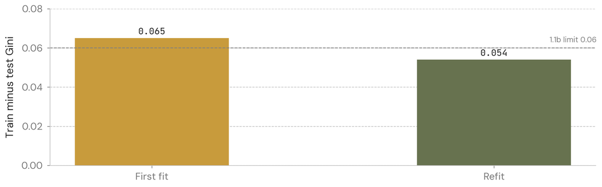

## Test Results: Challenger Against Scorecard

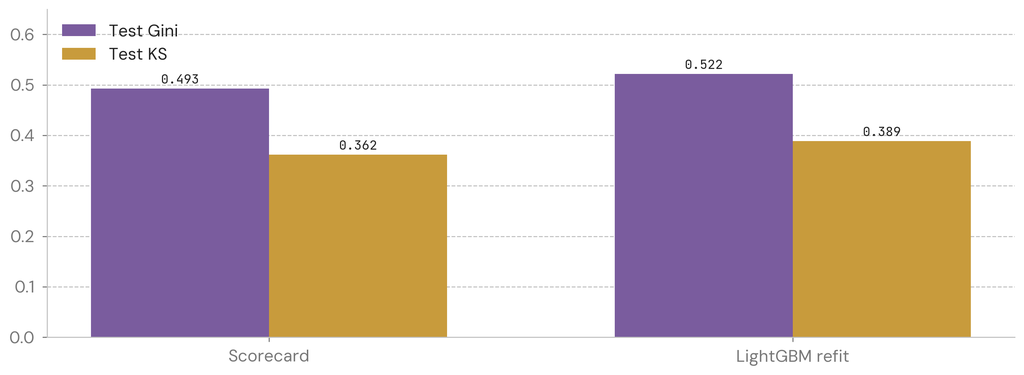

The refit’s Test Gini is 0.522, an uplift of +0.029. That is **0.0006 below the 0.03 rebuild line**. The Test Gini standard error is about 0.008, so the honest reading is “retain, and treat as borderline.”

## Rank Ordering and Calibration

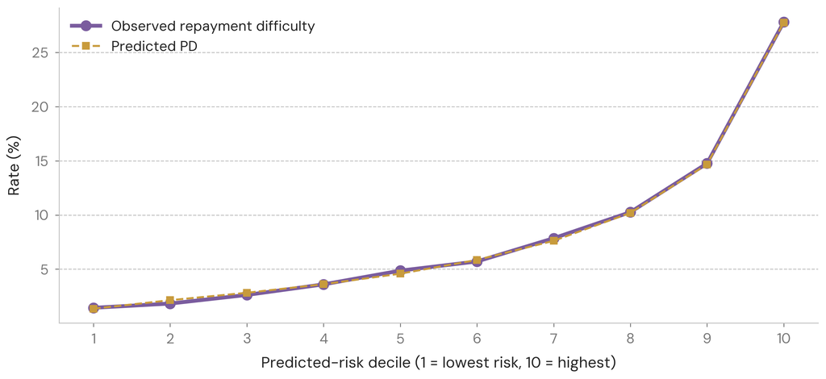

**Decile Reversals: 0 (criterion 1.1c). Mean predicted PD is 0.01 pp from the actual rate (criterion 1.1d).** Individual deciles differ by up to 0.3 pp, which is a calibration detail, not a ranking failure.

## What the Model Relies On

Gain importance shows how much each field improves the trees. It is the tree equivalent of the scorecard’s coefficients, but it does not show direction.

| Feature | Share of gain |
| --- | --- |
| External Credit Score 3 | 29.0% |
| External Credit Score 2 | 26.1% |
| Annuity-to-Credit Ratio | 12.0% |
| External Credit Score 1 | 8.8% |
| Credit-to-Goods Ratio (LVR) | 5.8% |
| Job Tenure | 5.7% |
| All other fields | 12.7% |

## Limitations

**Explainability.** A tree ensemble cannot be read field by field the way the scorecard can. Explaining an individual decision needs an extra tool, such as SHAP, which has not been run.

**Single model and seed.** One refit with one random seed. Seed sensitivity is not tested.

**Target definition.** Same payment-difficulty outcome as the scorecard. Not a regulatory default.

**Tuning.** No hyperparameter search. The refit was chosen by the train/test gap rule, and the test Gini was seen before the refit, so the result is not a fully blind test.

## Recommendation

**Keep the scorecard as champion.** The uplift is +0.029, in the “retain and review” band. The next step is to examine the tree’s strongest interactions as candidate terms for a v2 scorecard, which keeps the explainability.